# WoLKE CAEO 2025 Report

- Show All Code
- Hide All Code
- View Source

Author

Heiko Holz

Published

July 7, 2026

```r
library(this.path)
library(dplyr) #e.g. for select
library(tidyr) # for reshaping data
library(stringdist) #levenshtein
library(stringr) # for reshaping data
library(lme4)
library(lmerTest)
library(emmeans)
library(modelsummary)
library(kableExtra)
library(arsenal)
library(forcats)
library(ggplot2)
library(ggsci) # color palettes
library(jtools) # theme_apa etc.
library(papaja) # for apa reporting
library(sjPlot) # for tab_model
library(stargazer) # for stargazer tables
library(estimatr) # for lm_robust
library(patchwork) # for vertical plots
library(purrr)
```

```r
# load "env-analysis.RData" which contains all data needed for the analysis
load(file = "data/env-analysis.RData")
source(file = "functions.r") # all outsourced funtions, needs to be called after loading env

outcomes[outcomes == "AILITWolke"] <- "AILITwolke"
names(lmers_prepost_all) <- outcomes
# get the number of the terms in the model for the two treatment contrasts
tc2 <- nrow(summary(lmers_prepost_all[[1]])$coefficients)
tc1 <- tc2 - 1

# adjust AILITWolke in data and rename it to AILITwolke
names(data)[names(data) == "AILITWolke"] <- "AILITwolke"
levels(data_long$outcome)[
  levels(data_long$outcome) == "AILITWolke"
] <- "AILITwolke"
```

```r
data_wtf <- data %>%
  droplevels %>%
  mutate(
    location = factor(
      location,
      levels = c("PH Schwäbisch Gmünd", "PH Ludwigsburg")
    ),
    treatment = factor(ifelse(
      intervention == "control",
      "control",
      "intervention"
    ))
  )

## define contrast Control vs Exp1+Exp2 - vermutlich bessere version, da die Estimates "stimmen"
mat <- cbind(
  c(1 / 3, 1 / 3, 1 / 3), # Durchschnitt aller 3 Gruppen
  c(-1, .5, .5), # Vergleich Control vs Mittel der beiden Interventions-Gruppen
  c(0, -1, 1)
) # Vergleich Sprache vs MINT
contrasts.CvsExp <- solve(t(mat))[, -1]
colnames(contrasts.CvsExp) <- c("-c+STEM_language", "-STEM+language")
contrasts(data_wtf$intervention) <- contrasts.CvsExp

# GENDER
# female: -1/2
# male : +1/2
contrasts.gender <- cbind(c(-1 / 2, 1 / 2))
colnames(contrasts.gender) <- c("-m+f")
contrasts(data_wtf$gender) <- contrasts.gender

# LOCATION
# SG UE: -1/2
# L UE: +1/2
contrasts.location <- cbind(c(-1 / 2, 1 / 2))
colnames(contrasts.location) <- c("-SGUE+LUE")
contrasts(data_wtf$location) <- contrasts.location

# TIME
# pre: -1/2
# post: +1/2
contrasts.time <- cbind(c(-1 / 2, 1 / 2))
colnames(contrasts.time) <- c("-pre+post")
contrasts(data_wtf$time) <- contrasts.time

data <- data_wtf
# refit all lmer_prepost_all with new data
lmers_prepost_all <- lapply(
  outcomes,
  fit_lmer,
  groups,
  time,
  controls,
  random_terms_lmer,
  NULL,
  data = data
)
names(lmers_prepost_all) <- outcomes
```

```r
is_word <- !(knitr::is_html_output() | knitr::is_latex_output())

if (is_word) {
  library(flextable)
}

modelsummary_output <- ifelse(
  knitr::is_latex_output(),
  "latex_tabular",
  ifelse(knitr::is_html_output(), "kableExtra", "flextable")
)

adjust_table_for_word <- function(ft, width = 0) {
  ft <- flextable::autofit(ft)
  ft <- flextable::set_table_properties(ft, layout = "autofit", width = width)
  ft <- flextable::fontsize(ft, size = 10, part = "header")
  ft <- flextable::fontsize(ft, size = 8, part = "body")
  ft
}
```

# 1 Methods

## 1.1 Participants

```r
data_participants <- data %>%
  filter(time == "pre") %>%
  group_by(intervention, location, gender) %>%
  summarise(
    n = n(),
    n_complete = sum(complete.cases(.)),
    age_min = min(age, na.rm = T),
    age_max = max(age, na.rm = T),
    age_mean = mean(age, na.rm = T) %>% round(2),
    age_sd = sd(age, na.rm = T) %>% round(2),
    semester_min = min(semester, na.rm = T),
    semester_max = max(semester, na.rm = T),
    semester_mean = mean(semester, na.rm = T) %>% round(2),
    semester_sd = sd(semester, na.rm = T) %>% round(2)
  ) %>%
  ungroup()
```

The study involved pre-service teachers from two universities of education in Baden-Württemberg, Germany. Participants were divided into a **treatment group** consisting of two intervention groups (STEM and language course), and a **control group**. Students in the treatment groups self-selected the courses “AI in STEM/Language Education” as part of their compulsory elective studies. The control group was recruited from other STEM courses at University 1 during the same semester.

In total, $N=156$ students originally participated in the study ($N_c=65$ in the control group, $N_s= 53$ in the STEM course, and $N_l=38$ in the language course), of which $n=76$ completed both pre- and the posttest and were included in the analyses ($n_c = 19$, $n_s = 34$, $n_l = 23$).

Unfortunately, we observed a high drop-out rate between the pre- and posttest. We attribute this to several factors: First, the posttests were conducted in class close (one to two weeks) to the examination period, resulting in students not attending the in-person posttest sessions. For the control group, some lecturers executed the posttest during their teaching, while others did not. We suspect a high drop-out at the posttest for the control group due to both factors: students not attending the sessions close to the examination week and not conducting the tests at home or in their free study time.

```r
# render as table
format <- ifelse(
  knitr::is_html_output(),
  "markdown",
  ifelse(knitr::is_latex_output(), "latex", "markdown")
)

var_names <- list(
  gender = "Gender",
  age = "Age",
  semester = "Semester Number",
  students = "Study Level",
  isp = "Completed Integrated Semester Internship",
  subject1 = "Subject 1",
  subject2 = "Subject 2",
  studies = "Study Program",
  location = "University",
  TK = "Intelligent TK",
  TCK = "Intelligent TCK",
  TPK = "Intelligent TPK",
  TPACK_total = "Intelligent TPACK",
  AILIT = "AI Literacy",
  PU = "Perceived Usefulness",
  Ethics = "AI Ethics"
)

kable(
  summary(
    tableby(
      intervention ~
        location +
        age +
        gender +
        semester +
        students +
        TK +
        TCK +
        TPK +
        TPACK_total +
        Ethics +
        AILIT +
        PU,
      data %>%
        filter(time == "pre") %>%
        mutate(
          gender = factor(gender, labels = c("Female", "Male")),
          students = factor(students, labels = c("Bachelor", "Master"))
        ) %>%
        droplevels(),
      cat.test = "chisq",
      chisq.correct = T,
      control = tableby.control(test = T, total = T, digits = 2)
    ),
    labelTranslations = var_names,
    pfootnote = T,
    text = F
  ),
  escape = T,
  format = format,
  booktabs = T
)
```

Table 1: Demographic Data of the Three Experimental Groups.

|  | control (N=19) | stem (N=34) | language (N=23) | Total (N=76) | p value |
| --- | --- | --- | --- | --- | --- |
| **University** |  |  |  |  | < 0.001<sup>1</sup> |
| PH Schwäbisch Gmünd | 19 (100.0%) | 16 (47.1%) | 0 (0.0%) | 35 (46.1%) |  |
| PH Ludwigsburg | 0 (0.0%) | 18 (52.9%) | 23 (100.0%) | 41 (53.9%) |  |
| **Age** |  |  |  |  | 0.320<sup>2</sup> |
| Mean (SD) | 23.05 (3.17) | 24.65 (4.69) | 24.70 (3.47) | 24.26 (4.01) |  |
| Range | 20.00 - 31.00 | 21.00 - 41.00 | 22.00 - 39.00 | 20.00 - 41.00 |  |
| **Gender** |  |  |  |  | 0.021<sup>1</sup> |
| Female | 6 (31.6%) | 18 (52.9%) | 4 (17.4%) | 28 (36.8%) |  |
| Male | 13 (68.4%) | 16 (47.1%) | 19 (82.6%) | 48 (63.2%) |  |
| **Semester Number** |  |  |  |  | < 0.001<sup>2</sup> |
| Mean (SD) | 5.53 (2.48) | 7.03 (2.12) | 9.70 (2.79) | 7.46 (2.88) |  |
| Range | 2.00 - 10.00 | 4.00 - 10.00 | 6.00 - 19.00 | 2.00 - 19.00 |  |
| **Study Level** |  |  |  |  | 0.110<sup>1</sup> |
| Bachelor | 11 (57.9%) | 19 (55.9%) | 7 (30.4%) | 37 (48.7%) |  |
| Master | 8 (42.1%) | 15 (44.1%) | 16 (69.6%) | 39 (51.3%) |  |
| **Intelligent TK** |  |  |  |  | 0.047<sup>2</sup> |
| Mean (SD) | 3.53 (0.98) | 3.38 (0.78) | 2.91 (0.82) | 3.27 (0.87) |  |
| Range | 1.60 - 5.00 | 1.60 - 5.00 | 1.40 - 4.40 | 1.40 - 5.00 |  |
| **Intelligent TCK** |  |  |  |  | 0.031<sup>2</sup> |
| Mean (SD) | 3.22 (0.76) | 3.14 (0.73) | 2.68 (0.72) | 3.02 (0.76) |  |
| Range | 2.00 - 4.60 | 1.80 - 4.40 | 1.40 - 3.80 | 1.40 - 4.60 |  |
| **Intelligent TPK** |  |  |  |  | 0.001<sup>2</sup> |
| Mean (SD) | 2.98 (0.76) | 2.80 (0.76) | 2.19 (0.59) | 2.66 (0.77) |  |
| Range | 1.29 - 4.29 | 1.14 - 4.57 | 1.14 - 3.14 | 1.14 - 4.57 |  |
| **Intelligent TPACK** |  |  |  |  | 0.001<sup>2</sup> |
| Mean (SD) | 2.92 (0.74) | 2.74 (0.64) | 2.22 (0.51) | 2.63 (0.68) |  |
| Range | 1.68 - 4.50 | 1.32 - 3.92 | 1.39 - 3.29 | 1.32 - 4.50 |  |
| **AI Ethics** |  |  |  |  | 0.005<sup>2</sup> |
| Mean (SD) | 2.67 (0.79) | 2.54 (0.87) | 1.93 (0.68) | 2.39 (0.84) |  |
| Range | 1.50 - 4.00 | 1.17 - 4.33 | 1.00 - 4.00 | 1.00 - 4.33 |  |
| **AI Literacy** |  |  |  |  | 0.132<sup>2</sup> |
| Mean (SD) | 12.21 (3.61) | 13.94 (3.58) | 12.48 (2.87) | 13.07 (3.44) |  |
| Range | 8.00 - 20.00 | 6.00 - 20.00 | 6.00 - 18.00 | 6.00 - 20.00 |  |
| **Perceived Usefulness** |  |  |  |  | 0.520<sup>2</sup> |
| Mean (SD) | 4.01 (0.77) | 4.14 (0.70) | 3.93 (0.54) | 4.05 (0.67) |  |
| Range | 2.75 - 5.00 | 2.25 - 5.00 | 2.75 - 5.00 | 2.25 - 5.00 |  |

### 1.1.1 Effect Sizes for Group Differences for Covariates

```r
vars_num <- c("age", "semester") # numeric outcomes
vars_cat <- c("gender", "students") # categorical outcomes

d <- data %>%
  filter(time == "pre") %>%
  mutate(
    gender = factor(gender, labels = c("Female", "Male")),
    students = factor(students, labels = c("Bachelor", "Master"))
  )

# eta^2 for numeric outcomes
eta_num <- purrr::map_dfr(vars_num, function(v) {
  f <- as.formula(paste(v, "~ intervention"))
  m <- lm(f, data = d)
  es <- effectsize::eta_squared(m, partial = TRUE)
  tibble(
    variable = v,
    effect = "eta2",
    value = es$Eta2[1],
    interpretation = effectsize::interpret_eta_squared(value) %>% as.character
  )
})
```

```
For one-way between subjects designs, partial eta squared is equivalent
  to eta squared. Returning eta squared.
For one-way between subjects designs, partial eta squared is equivalent
  to eta squared. Returning eta squared.
```

```r
# Cramér's V for categorical outcomes
cv_cat <- purrr::map_dfr(vars_cat, function(v) {
  tab <- table(d[[v]], d$intervention)
  cv <- effectsize::cramers_v(tab)
  tibble(
    variable = v,
    effect = "cramers_v",
    value = cv$Cramers_v,
    interpretation = effectsize::interpret_cramers_v(value) %>% as.character
  )
})

effectsizes_covariates <- bind_rows(eta_num, cv_cat) %>%
  mutate(
    value = apa_num(value)
  )
effectsizes_covariates %>% kable
```

| variable | effect | value | interpretation |
| --- | --- | --- | --- |
| age | eta2 | 0.03 | small |
| semester | eta2 | 0.31 | large |
| gender | cramers_v | 0.28 | medium |
| students | cramers_v | 0.18 | small |

```r
cohens_d_two_groups <- purrr::map_dfr(vars_num, function(v) {
  es <- effectsize::cohens_d(v, "treatment", d, pooled = TRUE)
  tibble(
    variable = v,
    effect = "cohens_d",
    value = es$Cohens_d,
    interpretation = effectsize::interpret_cohens_d(value) %>% as.character
  )
})

phi_two_groups <- purrr::map_dfr(vars_cat, function(v) {
  tab <- table(d[[v]], d$treatment)
  phi <- effectsize::phi(tab, adjust = F)
  tibble(
    variable = v,
    effect = "phi",
    value = phi$phi,
    interpretation = effectsize::interpret_phi(value) %>% as.character
  )
})

# combine
effectsizes_covariates__two_groups <- bind_rows(
  cohens_d_two_groups,
  phi_two_groups
) %>%
  mutate(
    value = apa_num(value)
  )
```

## 1.2 Materials

### 1.2.1 Translation Process

The Intelligent-TPACK, originally developed by Celik (2023), is widely used to assess teachers’ knowledge for pedagogical and ethical AI use based on the technological, pedagogical, and content knowledge (TPACK) framework. However, while some studies translate and use subsets of the Intelligent-TPACK (e.g., Mah & Groß, 2024), no empirically validated German translations of the full Intelligent-TPACK exists.

Therefore, for the Intelligent-TPACK by Celik (2023) as well as for items from the AI ethics subscale from Chiu et al. (2024), we translated the original items in a participative multi-step process involving not just experts from the fields of computer science and education, but also (pre-service) teachers. For this, we applied the *Modified Direct Translation* that includes translators and experts discussing the wording until reaching agreement (Behling & Law, 2025): First, seven researchers and experts in AI ED (additionally including one English teacher and one student teacher of Computer Science and English) translated the items independently. Second, we compared all translations and marked the items that received different translations. In a third step, we performed a group workshop with all translators in which the marked items were discussed and dot voting was applied to decide on the most apporopriate translation. Finally, three items that were still marked as questionable were discussed and further adapted with a native English teacher who teaches at University 2.

The translation and validation of the Intelligent-TPACK is reported in detail in Authors (in prep.).

## 1.3 Analysis

To examine the efficacy of the interventions, we conducted separate ANCOVA models for each outcome measure. In each model, posttest scores were regressed on treatment condition while controlling for the respective pretest score, gender, and semester count, consistent with our three-group pretest–posttest design.

The treatment factor was dummy-coded using reversed Helmert contrasts to compare (i) the control group with the two intervention groups (“main treatment effect”) and (ii) the two intervention groups with each other. The control group was set as the reference group. Where applicable, pairwise comparisons were obtained with *emmeans* (Lenth, 2025).

Following the baseline equivalence criteria for randomized controlled trials proposed by the What Works Clearinghouse (Clearinghouse, 2022), we additionally considered baseline variables as covariates if group differences were statistically significant or if the standardized mean difference exceeded $d = .05$. We tested for baseline differences between treatment groups in age, gender, semester count, and study level (Bachelor’s vs. Master’s). Statistically significant group differences were found for gender and semester count. Therefore, these variables were included as covariates in all models (see Table 1).

That is, the final model for each outcome measure contained treatment, pretest score, gender, and semester count as fixed effects, and was specified as follows: `lm_robust(outcome_post ~ treatment + outcome_pre + gender + semester )`.

Posttest scores were standardized before running the analyses, so that the regression coefficients of the dummy variable indicating the respective treatment groups can directly be interpreted as Cohen’s d (Marsh et al., 2009).

To compute heteroscedasticity-consistent (HC) standard errors, we used the *lm_robust* function from the *estimatr* package (Blair et al., 2025), specifying the HC3 estimator, as recommended for small samples (J. S. Long & Ervin, 2000).

The criterion of statistical significance was set at $α=.05$.

### 1.3.1 Statistical Software

All analyses were conducted in *R* (R Core Team, 2024). Data were prepared using *dplyr* (Wickham et al., 2023), *tidyr* (Wickham et al., 2024), and *gtools* (Warnes et al., 2023). Tables were created with *arsenal* (Heinzen et al., 2021), *vtable* (Huntington-Klein, 2023), *modelsummary* (Arel-Bundock, 2022), and *kableExtra* (Zhu, 2024). Figures were produced using *ggplot2* (Wickham, 2016), *ggsci* (Xiao, 2024), and *jtools* (J. A. Long, 2022). The ANCOVA models were estimated using *lm_robust* from the *estimatr* package (Blair et al., 2025).

### 1.3.2 Data Preparation and Cleaning

```r
# get participants who only participated in pre or post test
data_dropouts <- data_all %>%
  group_by(code) %>%
  summarise(
    has_pre = any(time == "pre"),
    has_post = any(time == "post"),
    .groups = "drop"
  ) %>%
  summarise(
    n_pre_only = sum(has_pre & !has_post),
    n_post_only = sum(!has_pre & has_post),
    n_both = sum(has_pre & has_post)
  )
```

For data cleaning, we applied the following steps: First, we investigated which students, based on their pseudonyms, did not participate in both test sessions. Based on a string distance analysis using the Levenshtein distance (Levenshtein, 1966), we identified pseudonyms that were likely to belong to the same student but were entered slightly differently (e.g., due to typos or students who moved during the semester, as the address was part of their pseudonym). We then manually checked these pseudonyms and merged them if we believe they belonged to the same student. This resulted in $n=24$ students being merged. We then removed students who only participated at the pretest ($n=69$) or only at the posttest ($n=11$). Further, some students conducted the post test twice. In this case, we only considered their first response in the analyses and dropped the second.

As for some self-constructed items students could choose “I don’t understand the item” as a response option, we recoded these responses as missing values ($n=7$ responses to individual items).

#### 1.3.2.1 Für Paper

> Für das Paper würde ich nur folgenden Satz übernehmen (ich persönlich bevorzuge aktiv, aber ihr könnt auch beim passiv bleiben) und an anderer Stelle dann schreiben, dass die ausführlichen Analyseskripte und Daten in der Online-Supplement unter zugänglich sind:

All analyses were conducted in *R* (R Core Team, 2024). The ANCOVA models were estimated using *lm_robust* from the *estimatr* package (Blair et al., 2025). To compute heteroscedasticity-consistent (HC) standard errors, we specified the HC3 estimator, as recommended for small samples (J. S. Long & Ervin, 2000). Where applicable, pairwise comparisons were obtained with *emmeans* (Lenth, 2025).

# 2 Results

The descriptive statistics for students’ outcome measures at pretest and posttest by treatment group are shown in the top half of Figure 1, Figure 2, and Figure 3. At the bottom half of these figures, the ANCOVA-adjusted predicted posttest scores are displayed, with predictions standardized to a common pretest value and adjusted for gender and semester count.

For all outcome measures, we first report the main effect of treatment condition (i.e., the difference between the control group and the intervention groups) on posttest scores after adjusting for pretest scores, gender, and semester count. We then report the planned contrasts comparing the control group with the intervention groups and, subsequently, the contrast between the two intervention groups (STEM vs. language course).

**Note**

Man könnte jetzt hier auch sagen (da bei ANCOVA der Change dasselbe ergibt):

> on students’ change in the respective outcome measures from pretest to posttest, after adjusting for pretest …

```r
# reshape data to wide format for ancova
data_wide <- data %>%
  pivot_wider(
    id_cols = c(
      code,
      intervention,
      group,
      gender,
      semester,
      students,
      location
    ),
    names_from = time,
    values_from = all_of(outcomes)
  ) %>%
  mutate(
    # scale the posttest score so that the estimates are approximations of Cohen's d
    across(all_of(outcomes %>% paste0("_post")), scale),

    treatment = factor(ifelse(
      intervention == "control",
      "control",
      "intervention"
    ))
  )

data_wide_unscaled <- data %>%
  pivot_wider(
    id_cols = c(
      code,
      intervention,
      group,
      gender,
      semester,
      students,
      location
    ),
    names_from = time,
    values_from = all_of(outcomes)
  ) %>%
  mutate(
    treatment = factor(ifelse(
      intervention == "control",
      "control",
      "intervention"
    ))
  )

contrasts.treatment <- cbind(c(-1 / 2, 1 / 2))
colnames(contrasts.treatment) <- c("-c+t")
contrasts(data_wide$treatment) <- contrasts.treatment

ancovas <- lapply(
  outcomes,
  fit_ancova,
  groups,
  # we remove University as a covariate as we only have control students at University 2
  setdiff(controls, "location"),
  "HC3",
  data_wide
)
names(ancovas) <- outcomes
tc2 <- nrow(summary(ancovas[[1]])$coefficients)
tc1 <- tc2 - 1

ancovas_unscaled <- lapply(
  outcomes,
  fit_ancova,
  groups,
  # we remove University as a covariate as we only have control students at University 2
  setdiff(controls, "location"),
  "HC3",
  data_wide_unscaled
)
names(ancovas_unscaled) <- outcomes

ancovas_two_groups <- lapply(
  outcomes,
  fit_ancova,
  "treatment",
  setdiff(controls, "location"),
  "HC3",
  data_wide
)
names(ancovas_two_groups) <- outcomes
```

## 2.1 AI Literacy

Descriptive results of students’ AI literacy scores are shown in the upper panel of Figure 1. The lower panel displays ANCOVA-adjusted predictions standardized to a common pretest value and controlled for gender and semester count. The results of the ANCOVA models are listed in Table 2.

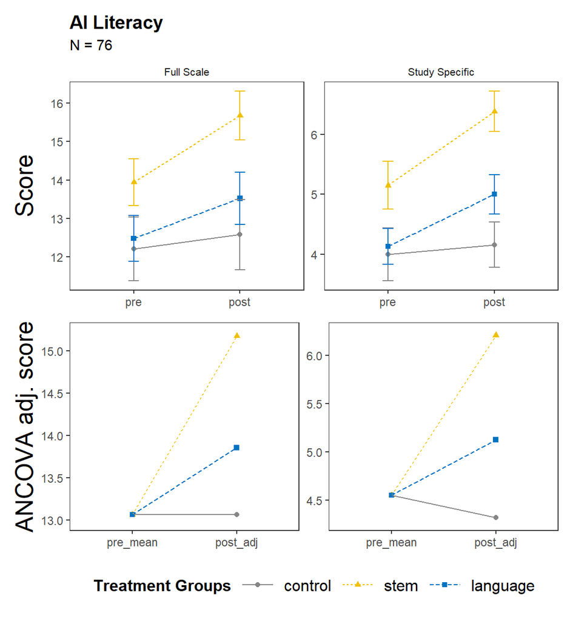

Figure 1: Descriptive Statistics of Students’ AI Literacy Scores Over Time by Treatment Group.

```r
ft_ailit_ancova <- modelsummary_models(
  ancovas[names(ancovas) %in% c("AILIT", "AILITwolke")],
  outcomes = c("AILIT", "AILITwolke"),
  output = modelsummary_output,
  # coef_rename = c("genderMännlich" = "Geschlecht")
) # %>%   kableExtra::scroll_box(width = "100%")

if (is_word) {
  ft_ailit_ancova <- adjust_table_for_word(ft_ailit_ancova, width = .75)
}
ft_ailit_ancova
```

Table 2: ANCOVA results for scaled posttest AI Literacy (full scale and WOLKE study-specific subset), adjusted for pretest, gender, and semester count.

|  | AILIT β | AILIT SE | AILIT t | AILIT p | AILITwolke β | AILITwolke SE | AILITwolke t | AILITwolke p |
| --- | --- | --- | --- | --- | --- | --- | --- | --- |
| (Intercept) | -2.24*** | 0.54 | -4.15 | <0.001 | -0.99* | 0.39 | -2.50 | 0.015 |
| intervention-c+STEM_language | 0.28 | 0.27 | 1.04 | 0.301 | 0.61** | 0.23 | 2.69 | 0.009 |
| intervention-STEM+language | -0.42+ | 0.24 | -1.74 | 0.086 | -0.67* | 0.28 | -2.41 | 0.019 |
| pretest | 0.15*** | 0.03 | 4.49 | <0.001 | 0.15* | 0.06 | 2.39 | 0.020 |
| gender-m+f | -0.03 | 0.24 | -0.11 | 0.909 | 0.16 | 0.24 | 0.65 | 0.515 |
| semester | 0.03 | 0.04 | 0.88 | 0.381 | 0.03 | 0.04 | 0.64 | 0.526 |
| Num.Obs. | 76 |  |  |  | 76 |  |  |  |
| R2 | 0.354 |  |  |  | 0.309 |  |  |  |
| R2 Adj. | 0.308 |  |  |  | 0.259 |  |  |  |
| AIC | 195.5 |  |  |  | 200.6 |  |  |  |
| BIC | 211.8 |  |  |  | 216.9 |  |  |  |
| RMSE | 0.80 |  |  |  | 0.83 |  |  |  |

```r
if (!is_word) {
  cat("#### Pairwise Contrasts Between Groups")
}
```

#### 2.1.0.1 Pairwise Contrasts Between Groups

```r
# pairwise between contrasts (no multiplicity adjustment)
ailit_ancova_between_contrasts <- lapply(ancovas[1:3], function(m) {
  emmeans(m, ~intervention) %>%
    contrast(interaction = "pairwise", adjust = "none")
})
if (!is_word) {
  print(ailit_ancova_between_contrasts)
}
```

```
$AILIT
 intervention_pairwise estimate    SE df t.ratio p.value
 control - stem         -0.4928 0.276 70  -1.785  0.0786
 control - language     -0.0699 0.314 70  -0.222  0.8246
 stem - language         0.4229 0.243 70   1.741  0.0861

Results are averaged over the levels of: gender

$AILITwolke
 intervention_pairwise estimate    SE df t.ratio p.value
 control - stem          -0.947 0.264 70  -3.581  0.0006
 control - language      -0.279 0.269 70  -1.038  0.3029
 stem - language          0.668 0.277 70   2.411  0.0185

Results are averaged over the levels of: gender

$AILITShort
 intervention_pairwise estimate    SE df t.ratio p.value
 control - stem          -0.871 0.302 70  -2.882  0.0052
 control - language      -0.383 0.351 70  -1.092  0.2784
 stem - language          0.487 0.279 70   1.749  0.0846

Results are averaged over the levels of: gender
```

### 2.1.1 AI Literacy – Full Scale

For the full AI literacy scale, students in the intervention groups did not show significantly greater improvement than students in the control group, $\beta$ = 0.28, *SE* = 0.27, *t*(70) = 1.04, *p* = .301. The two intervention groups also did not differ significantly from each other, $\beta$ = -0.42, *SE* = 0.24, *t*(70) = -1.74, *p* = .086, although the estimate suggests a small-to-medium effect for the STEM group.

Looking at the post-hoc contrasts, the contrast between the control and STEM groups was marginally significant, $\beta$ = -0.49, *SE* = 0.28, *t*(70) = -1.78, *p* = .079, with a small-to-medium effect in favor of the STEM group. Similarly, the contrast between STEM and language groups was marginally significant with a small-to-medium effect size, $\beta$ = 0.42, *SE* = 0.24, *t*(70) = 1.74, *p* = .086.

### 2.1.2 AI Literacy – Study-Specific Subset

For the study-specific subset of the AI literacy items, students in the intervention groups showed significantly greater improvements than students in the control group, $\beta$ = 0.61, *SE* = 0.23, *t*(70) = 2.69, *p* = .009, with a medium-sized effect in favor of the intervention groups. In addition, the two intervention groups differed significantly, $\beta$ = -0.67, *SE* = 0.28, *t*(70) = -2.41, *p* = .019, with the estimate indicating a medium-sized advantage for the STEM group.

As can be seen in Figure 1, students in both intervention groups showed descriptively higher AI literacy improvement than students in the control group. Post-hoc contrasts showed that students in the STEM course scored significantly higher after intervention on the study-specific AI literacy subset than students in the control group, $\beta$ = -0.95, *SE* = 0.26, *t*(70) = -3.58, *p* < .001, with a large effect in favor of the STEM group, whereas the difference between students in the language course and the control group was not statistically significant, $\beta$ = -0.28, *SE* = 0.27, *t*(70) = -1.04, *p* = .303.

## 2.2 Intelligent TPACK and AI Ethics

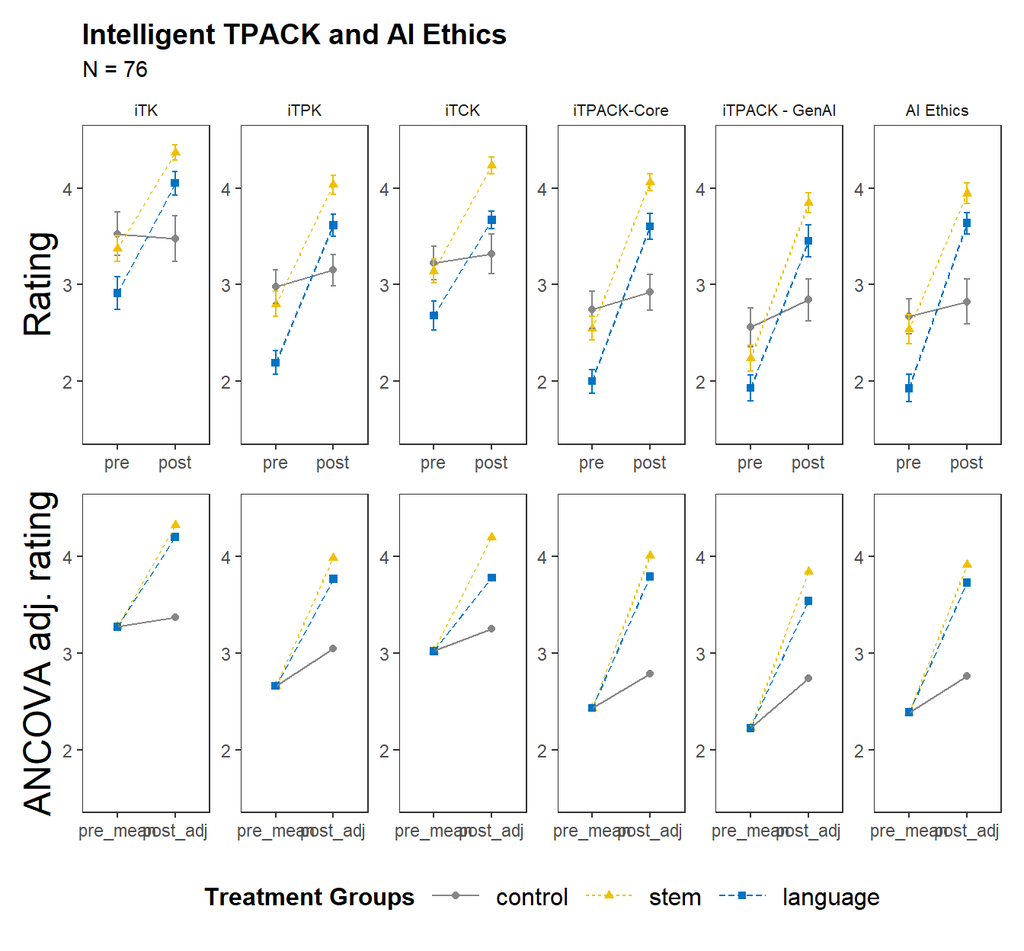

Figure 2: Descriptive Statistics of Students’ Intelligent TPACK and AI Ethics Ratings Over Time by Treatment Group.

```r
ft_ancova <- modelsummary_models(
  ancovas[grepl("^(T|Ethics)", names(ancovas))],
  outcomes = outcomes %>% grep("^(T|Ethics)", ., value = TRUE),
  output = modelsummary_output,
  # coef_rename = c("genderMännlich" = "Geschlecht")
) # %>%   kableExtra::scroll_box(width = "100%")

if (is_word) {
  ft_ancova <- adjust_table_for_word(ft_ancova, width = 1)
}
ft_ancova
```

Table 3: ANCOVA results for scaled posttest Intelligent TPACK and AI Ethics, adjusted for pretest, gender, and semester count.

|  | TK β | TK SE | TK t | TK p | TPK β | TPK SE | TPK t | TPK p | TCK β | TCK SE | TCK t | TCK p | TPACKce β | TPACKce SE | TPACKce t | TPACKce p | TPACKgenai β | TPACKgenai SE | TPACKgenai t | TPACKgenai p | Ethics β | Ethics SE | Ethics t | Ethics p |
| --- | --- | --- | --- | --- | --- | --- | --- | --- | --- | --- | --- | --- | --- | --- | --- | --- | --- | --- | --- | --- | --- | --- | --- | --- |
| (Intercept) | -2.13*** | 0.49 | -4.31 | <0.001 | -1.89** | 0.66 | -2.85 | 0.006 | -1.75** | 0.61 | -2.85 | 0.006 | -1.80** | 0.57 | -3.17 | 0.002 | -1.41** | 0.52 | -2.71 | 0.008 | -0.50 | 0.57 | -0.88 | 0.383 |
| intervention-c+STEM_language | 1.08** | 0.34 | 3.20 | 0.002 | 1.01** | 0.31 | 3.25 | 0.002 | 0.91** | 0.29 | 3.08 | 0.003 | 1.30*** | 0.27 | 4.79 | <0.001 | 0.89** | 0.29 | 3.09 | 0.003 | 1.31*** | 0.29 | 4.46 | <0.001 |
| intervention-STEM+language | -0.17 | 0.20 | -0.83 | 0.408 | -0.49+ | 0.28 | -1.77 | 0.081 | -0.58* | 0.23 | -2.51 | 0.014 | -0.33 | 0.22 | -1.53 | 0.130 | -0.45+ | 0.25 | -1.77 | 0.081 | -0.05 | 0.24 | -0.21 | 0.836 |
| pretest | 0.55*** | 0.12 | 4.81 | <0.001 | 0.48* | 0.19 | 2.50 | 0.015 | 0.45** | 0.16 | 2.87 | 0.005 | 0.56*** | 0.15 | 3.77 | <0.001 | 0.35* | 0.16 | 2.28 | 0.026 | 0.24+ | 0.13 | 1.80 | 0.076 |
| gender-m+f | -0.22 | 0.20 | -1.10 | 0.273 | -0.04 | 0.21 | -0.18 | 0.860 | -0.34+ | 0.17 | -1.98 | 0.052 | -0.17 | 0.20 | -0.89 | 0.378 | -0.28 | 0.22 | -1.32 | 0.192 | -0.34+ | 0.21 | -1.67 | 0.100 |
| semester | 0.03 | 0.03 | 0.92 | 0.359 | 0.07 | 0.04 | 1.64 | 0.105 | 0.04 | 0.03 | 1.43 | 0.157 | 0.04 | 0.05 | 0.93 | 0.357 | 0.07+ | 0.04 | 1.68 | 0.098 | -0.02 | 0.07 | -0.28 | 0.783 |
| Num.Obs. | 76 |  |  |  | 76 |  |  |  | 76 |  |  |  | 76 |  |  |  | 76 |  |  |  | 76 |  |  |  |
| R2 | 0.471 |  |  |  | 0.395 |  |  |  | 0.437 |  |  |  | 0.523 |  |  |  | 0.336 |  |  |  | 0.366 |  |  |  |
| R2 Adj. | 0.433 |  |  |  | 0.352 |  |  |  | 0.396 |  |  |  | 0.489 |  |  |  | 0.289 |  |  |  | 0.321 |  |  |  |
| AIC | 180.3 |  |  |  | 190.5 |  |  |  | 185.1 |  |  |  | 172.4 |  |  |  | 197.5 |  |  |  | 194.0 |  |  |  |
| BIC | 196.6 |  |  |  | 206.8 |  |  |  | 201.4 |  |  |  | 188.7 |  |  |  | 213.9 |  |  |  | 210.4 |  |  |  |
| RMSE | 0.72 |  |  |  | 0.77 |  |  |  | 0.75 |  |  |  | 0.69 |  |  |  | 0.81 |  |  |  | 0.79 |  |  |  |

### 2.2.1 Intelligent TK

For Intelligent TK, students in the intervention groups reported significantly greater improvement than students in the control group, $\beta$ = 1.08, *SE* = 0.34, *t*(70) = 3.20, *p* = .002, with a large positive effect size in favor of the intervention groups. The two intervention groups did not differ significantly from each other, $\beta$ = -0.17, *SE* = 0.20, *t*(70) = -0.83, *p* = .408.

### 2.2.2 Intelligent TPK

For Intelligent TPK, students in the intervention groups reported significantly greater improvement than students in the control group, $\beta$ = 1.01, *SE* = 0.31, *t*(70) = 3.25, *p* = .002, with a large positive effect size in favor of the intervention groups. The two intervention groups did not differ significantly from each other, although the small-to-medium effect size was marginally significant in favor of the STEAM group, $\beta$ = -0.49, *SE* = 0.28, *t*(70) = -1.77, *p* = .081, with a small-to-medium effect size in favor of the STEM group.

### 2.2.3 Intelligent TCK

For Intelligent TCK, students in the intervention groups reported significantly greater improvement than students in the control group, $\beta$ = 0.91, *SE* = 0.29, *t*(70) = 3.08, *p* = .003, with a large positive effect size in favor of the intervention groups. Notably, this was the only subscale for which the two intervention groups also differed significantly, $\beta$ = -0.58, *SE* = 0.23, *t*(70) = -2.51, *p* = .014, with a medium-sized effect size in favor of the STEM group.

### 2.2.4 Intelligent TPACK Core

For the Intelligent TPACK core subscale, students in the intervention groups reported significantly greater improvement than students in the control group, $\beta$ = 1.30, *SE* = 0.27, *t*(70) = 4.79, *p* < .001, with a large positive effect size in favor of the intervention groups. The two intervention groups did not differ significantly from each other, $\beta$ = -0.33, *SE* = 0.22, *t*(70) = -1.53, *p* = .130.

### 2.2.6 AI Ethics

For AI ethics, students in the intervention groups reported significantly greater improvement than students in the control group, $\beta$ = 1.31, *SE* = 0.29, *t*(70) = 4.46, *p* < .001, indicating a large positive effect in favor of the intervention groups. The two intervention groups did not differ significantly from each other, $\beta$ = -0.05, *SE* = 0.24, *t*(70) = -0.21, *p* = .836.

## 2.3 Perceived Usefulness

Descriptive results of pre-service teacher students’ perceived usefulness of AI in their teaching as well as the ANCOVA-adjusted posttest ratings are listed in Figure 3, while the results of the ANCOVA analysis for perceived usefulness are presented in Table 4.

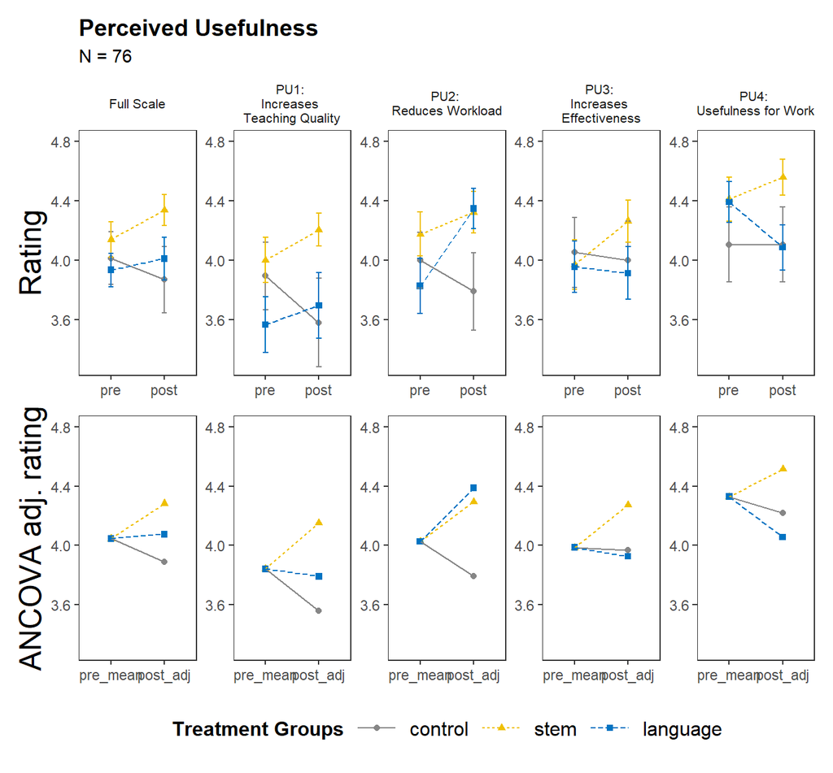

Figure 3: Descriptive Statistics of Students’ Perceived Usefulness Ratings Over Time by Treatment Group.

```r
ft_pu_ancova <- modelsummary_models(
  ancovas[grepl("^(PU)", names(ancovas))],
  outcomes = outcomes %>% grep("^(PU)", ., value = TRUE),
  output = modelsummary_output,
  # coef_rename = c("genderMännlich" = "Geschlecht")
) # %>%   kableExtra::scroll_box(width = "100%")

if (is_word) {
  ft_pu_ancova <- ft_pu_ancova %>% adjust_table_for_word()
}
ft_pu_ancova
```

Table 4: ANCOVA results for scaled posttest of each Perceived Usefulness item, adjusted for pretest, gender, and semester count.

|  | PU β | PU SE | PU t | PU p | PU1 β | PU1 SE | PU1 t | PU1 p | PU2 β | PU2 SE | PU2 t | PU2 p | PU3 β | PU3 SE | PU3 t | PU3 p | PU4 β | PU4 SE | PU4 t | PU4 p |
| --- | --- | --- | --- | --- | --- | --- | --- | --- | --- | --- | --- | --- | --- | --- | --- | --- | --- | --- | --- | --- |
| (Intercept) | -3.71*** | 0.82 | -4.51 | <0.001 | -1.72** | 0.57 | -3.00 | 0.004 | -1.41* | 0.66 | -2.15 | 0.035 | -2.41*** | 0.67 | -3.62 | <0.001 | -3.04*** | 0.80 | -3.81 | <0.001 |
| intervention-c+STEM_language | 0.17 | 0.25 | 0.68 | 0.499 | 0.25 | 0.33 | 0.74 | 0.462 | 0.42 | 0.40 | 1.06 | 0.293 | -0.06 | 0.28 | -0.20 | 0.844 | -0.10 | 0.25 | -0.43 | 0.671 |
| intervention-STEM+language | -0.38 | 0.26 | -1.44 | 0.154 | -0.37 | 0.32 | -1.15 | 0.254 | 0.01 | 0.24 | 0.05 | 0.957 | -0.44+ | 0.26 | -1.69 | 0.096 | -0.59* | 0.27 | -2.19 | 0.032 |
| pretest | 0.78*** | 0.17 | 4.68 | <0.001 | 0.34* | 0.13 | 2.56 | 0.013 | 0.23+ | 0.13 | 1.80 | 0.077 | 0.49*** | 0.11 | 4.40 | <0.001 | 0.60*** | 0.15 | 3.96 | <0.001 |
| gender-m+f | -0.27 | 0.19 | -1.46 | 0.149 | -0.37+ | 0.21 | -1.77 | 0.082 | -0.24 | 0.26 | -0.92 | 0.361 | -0.30 | 0.20 | -1.50 | 0.137 | -0.32 | 0.19 | -1.66 | 0.102 |
| semester | 0.07+ | 0.04 | 1.92 | 0.059 | 0.05 | 0.04 | 1.32 | 0.192 | 0.07 | 0.05 | 1.40 | 0.165 | 0.06 | 0.06 | 1.10 | 0.275 | 0.06 | 0.06 | 1.02 | 0.312 |
| Num.Obs. | 76 |  |  |  | 76 |  |  |  | 76 |  |  |  | 76 |  |  |  | 76 |  |  |  |
| R2 | 0.444 |  |  |  | 0.254 |  |  |  | 0.148 |  |  |  | 0.337 |  |  |  | 0.424 |  |  |  |
| R2 Adj. | 0.404 |  |  |  | 0.201 |  |  |  | 0.087 |  |  |  | 0.290 |  |  |  | 0.383 |  |  |  |
| AIC | 184.1 |  |  |  | 206.4 |  |  |  | 216.5 |  |  |  | 197.4 |  |  |  | 186.7 |  |  |  |
| BIC | 200.4 |  |  |  | 222.7 |  |  |  | 232.8 |  |  |  | 213.8 |  |  |  | 203.0 |  |  |  |
| RMSE | 0.74 |  |  |  | 0.86 |  |  |  | 0.92 |  |  |  | 0.81 |  |  |  | 0.75 |  |  |  |

Regarding the overall perceived usefulness of AI in their teaching, we did not find a significant treatment effect on students’ perceived usefulness ratings. Students in the intervention groups did not differ significantly from students in the control group in their pretest-adjusted posttest ratings, $\beta$ = 0.17, *SE* = 0.25, *t*(70) = 0.68, *p* = .499. The two intervention groups also did not differ significantly from each other, $\beta$ = -0.38, *SE* = 0.26, *t*(70) = -1.44, *p* = .154. For an overview of the ANCOVA results, see Table 4.

```r
pu_between_contrasts <- lapply(
  ancovas[grepl("^(PU)", names(ancovas))],
  function(m) {
    emmeans(m, ~intervention) %>%
      contrast(interaction = "pairwise", adjust = "none")
  }
)
if (!is_word) {
  print(pu_between_contrasts)
}
```

```
$PU
 intervention_pairwise estimate    SE df t.ratio p.value
 control - stem         -0.3553 0.247 70  -1.438  0.1548
 control - language      0.0224 0.306 70   0.073  0.9417
 stem - language         0.3778 0.262 70   1.442  0.1537

Results are averaged over the levels of: gender

$PU1
 intervention_pairwise estimate    SE df t.ratio p.value
 control - stem         -0.4316 0.290 70  -1.489  0.1409
 control - language     -0.0598 0.434 70  -0.138  0.8909
 stem - language         0.3718 0.324 70   1.149  0.2544

Results are averaged over the levels of: gender

$PU2
 intervention_pairwise estimate    SE df t.ratio p.value
 control - stem          -0.416 0.375 70  -1.110  0.2706
 control - language      -0.429 0.454 70  -0.945  0.3478
 stem - language         -0.013 0.239 70  -0.054  0.9568

Results are averaged over the levels of: gender

$PU3
 intervention_pairwise estimate    SE df t.ratio p.value
 control - stem          -0.163 0.275 70  -0.594  0.5545
 control - language       0.274 0.340 70   0.807  0.4224
 stem - language          0.438 0.260 70   1.686  0.0963

Results are averaged over the levels of: gender

$PU4
 intervention_pairwise estimate    SE df t.ratio p.value
 control - stem          -0.191 0.243 70  -0.787  0.4342
 control - language       0.400 0.313 70   1.279  0.2052
 stem - language          0.591 0.270 70   2.191  0.0318

Results are averaged over the levels of: gender
```

When investigating the individual items of the perceived usefulness scale, we did not find any significant differences between the control and intervention groups for any of the items. For item PU3, we observed a tendency toward a medium-sized effect between the intervention groups, $\beta$ = 0.44, *SE* = 0.26, *t*(70) = 1.69, *p* = .096, with higher values in the STEM group than in the language group. For the same comparison on item PU4, we found a significant difference, $\beta$ = 0.59, *SE* = 0.27, *t*(70) = 2.19, *p* = .032, again indicating a medium-sized effect in favor of the STEM group.

## 2.4 Two-Groups Ancova

**Note**

Brauchen wir diesen Teil überhaupt, wird der besprochen?

**Antwort Heiko**: Ich würde ihn - wenn überhaupt - nur ins online-supplement packen und dann ggf. im Fließtext erwähnen, dass wir als Robustheitscheck auch die ANCOVA mit einer einfachen Dummy-Kodierung für die Intervention (Studierende aus STEM und language zusammengefasst) vs. Control Gruppe durchgeführt haben. Und dass die Ergebnisse dieselben Aussagen stützen (falls das so ist :D).

Die ganzen Effekte werden glaube ich einfach stärker, weil wir mehr STEM and language Studierende haben und die dann den gemittelten Effekt pushen.

```r
modelsummary_models(
  ancovas_two_groups,
  outcomes = outcomes,
  output = modelsummary_output
)
```

Table 5: Summary of Multiple Linear Regression Models for Two Treatment Groups.

|  | AILIT β | AILIT SE | AILIT t | AILIT p | AILITwolke β | AILITwolke SE | AILITwolke t | AILITwolke p | AILITShort β | AILITShort SE | AILITShort t | AILITShort p | TK β | TK SE | TK t | TK p | TPK β | TPK SE | TPK t | TPK p | TCK β | TCK SE | TCK t | TCK p | TPACKce β | TPACKce SE | TPACKce t | TPACKce p | TPACKgenai β | … |
| --- | --- | --- | --- | --- | --- | --- | --- | --- | --- | --- | --- | --- | --- | --- | --- | --- | --- | --- | --- | --- | --- | --- | --- | --- | --- | --- | --- | --- | --- | --- |
| (Intercept) | -2.03*** | 0.49 | -4.12 | <0.001 | -0.80+ | 0.41 | -1.96 | 0.054 | -0.69 | 0.41 | -1.65 | 0.103 | -2.24*** | 0.48 | -4.62 | <0.001 | -1.96** | 0.69 | -2.83 | 0.006 | -1.66* | 0.64 | -2.61 | 0.011 | -1.92** | 0.58 | -3.29 | 0.002 | -1.29* | … |
| treatment-c+t | 0.39 | 0.26 | 1.50 | 0.138 | 0.77** | 0.23 | 3.34 | 0.001 | 0.75** | 0.28 | 2.66 | 0.010 | 1.12*** | 0.32 | 3.56 | <0.001 | 1.14*** | 0.29 | 3.95 | <0.001 | 1.05*** | 0.28 | 3.77 | <0.001 | 1.39*** | 0.25 | 5.47 | <0.001 | 1.00*** | … |
| pretest | 0.15*** | 0.03 | 4.51 | <0.001 | 0.16* | 0.06 | 2.56 | 0.013 | 0.17* | 0.07 | 2.32 | 0.023 | 0.56*** | 0.11 | 5.05 | <0.001 | 0.53** | 0.18 | 2.99 | 0.004 | 0.47** | 0.15 | 3.07 | 0.003 | 0.59*** | 0.15 | 4.02 | <0.001 | 0.35* | … |
| gender-m+f | -0.14 | 0.24 | -0.58 | 0.563 | -0.01 | 0.24 | -0.03 | 0.974 | 0.22 | 0.26 | 0.85 | 0.400 | -0.26 | 0.20 | -1.30 | 0.198 | -0.14 | 0.20 | -0.71 | 0.479 | -0.49** | 0.17 | -2.87 | 0.005 | -0.25 | 0.20 | -1.27 | 0.208 | -0.40+ | … |
| semester | 0.00 | 0.03 | 0.14 | 0.890 | -0.02 | 0.04 | -0.47 | 0.643 | -0.04 | 0.03 | -1.03 | 0.307 | 0.02 | 0.03 | 0.67 | 0.502 | 0.04 | 0.04 | 0.97 | 0.333 | 0.01 | 0.03 | 0.20 | 0.839 | 0.02 | 0.04 | 0.54 | 0.593 | 0.04 | … |
| Num.Obs. | 76 |  |  |  | 76 |  |  |  | 76 |  |  |  | 76 |  |  |  | 76 |  |  |  | 76 |  |  |  | 76 |  |  |  | 76 | … |
| R2 | 0.330 |  |  |  | 0.249 |  |  |  | 0.205 |  |  |  | 0.467 |  |  |  | 0.364 |  |  |  | 0.392 |  |  |  | 0.509 |  |  |  | 0.309 | … |
| R2 Adj. | 0.292 |  |  |  | 0.207 |  |  |  | 0.160 |  |  |  | 0.437 |  |  |  | 0.328 |  |  |  | 0.358 |  |  |  | 0.481 |  |  |  | 0.270 | … |
| AIC | 196.2 |  |  |  | 204.9 |  |  |  | 209.3 |  |  |  | 178.8 |  |  |  | 192.2 |  |  |  | 188.8 |  |  |  | 172.7 |  |  |  | 198.6 | … |
| BIC | 210.2 |  |  |  | 218.8 |  |  |  | 223.3 |  |  |  | 192.8 |  |  |  | 206.2 |  |  |  | 202.8 |  |  |  | 186.7 |  |  |  | 212.5 | … |
| RMSE | 0.81 |  |  |  | 0.86 |  |  |  | 0.89 |  |  |  | 0.73 |  |  |  | 0.79 |  |  |  | 0.77 |  |  |  | 0.70 |  |  |  | 0.83 | … |

## References

Arel-Bundock, V. (2022). modelsummary: Data and model summaries in R. *Journal of Statistical Software*, *103*(1), 1–23. https://doi.org/10.18637/jss.v103.i01

Authors. (in prep.). *Development and Validation of a German Version of the Intelligent-TPACK*.

Behling, O., & Law, K. (2025). *Translating Questionnaires and Other Research Instruments*. SAGE Publications, Inc. https://doi.org/10.4135/9781412986373

Blair, G., Cooper, J., Coppock, A., Humphreys, M., & Sonnet, L. (2025). *Estimatr: Fast estimators for design-based inference*. https://declaredesign.org/r/estimatr/

Celik, I. (2023). Towards Intelligent-TPACK: An empirical study on teachers’ professional knowledge to ethically integrate artificial intelligence (AI)-based tools into education. *Computers in Human Behavior*, *138*, 107468. https://doi.org/10.1016/j.chb.2022.107468

Chiu, T. K. F., Ahmad, Z., & Çoban, M. (2024). Development and validation of teacher artificial intelligence (AI) competence self-efficacy (TAICS) scale. *Education and Information Technologies*. https://doi.org/10.1007/s10639-024-13094-z

Clearinghouse, W. W. (2022). What works clearinghouse procedures and standards handbook, version 5.0. US department of education, institute of education sciences. *National Center for Education Evaluation and Regional Assistance (NCEE)*. https://ies.ed.gov/ncee/wwc/Handbooks

Heinzen, E., Sinnwell, J., Atkinson, E., Gunderson, T., & Dougherty, G. (2021). *Arsenal: An arsenal of ’r’ functions for large-scale statistical summaries*. https://github.com/mayoverse/arsenal

Huntington-Klein, N. (2023). *Vtable: Variable table for variable documentation*. https://nickch-k.github.io/vtable/

Lenth, R. V. (2025). *Emmeans: Estimated marginal means, aka least-squares means*. https://rvlenth.github.io/emmeans/

Levenshtein, V. I. (1966). Binary Codes Capable of Correcting Deletions, Insertions and Reversals. *Soviet Physics Doklady*, *10*(8). https://nymity.ch/sybilhunting/pdf/Levenshtein1966a.pdf

Long, J. A. (2022). *Jtools: Analysis and presentation of social scientific data*. https://cran.r-project.org/package=jtools

Long, J. S., & Ervin, L. H. (2000). Using heteroscedasticity consistent standard errors in the linear regression model. *The American Statistician*, *54*(3), 217–224. https://doi.org/10.1080/00031305.2000.10474549

Mah, D.-K., & Groß, N. (2024). Artificial intelligence in higher education: Exploring faculty use, self-efficacy, distinct profiles, and professional development needs. *International Journal of Educational Technology in Higher Education*, *21*(1), 58. https://doi.org/10.1186/s41239-024-00490-1

Marsh, H. W., Lüdtke, O., Robitzsch, A., Trautwein, U., Asparouhov, T., Muthén, B., & Nagengast, B. (2009). Doubly-Latent Models of School Contextual Effects: Integrating Multilevel and Structural Equation Approaches to Control Measurement and Sampling Error. *Multivariate Behavioral Research*, *44*(6), 764–802. https://doi.org/10.1080/00273170903333665

R Core Team. (2024). *R: A language and environment for statistical computing*. R Foundation for Statistical Computing. https://www.R-project.org/

Warnes, G. R., Bolker, B., Lumley, T., Magnusson, A., Venables, B., Ryodan, G., & Moeller, S. (2023). *Gtools: Various r programming tools*. https://github.com/r-gregmisc/gtools

Wickham, H. (2016). *ggplot2: Elegant graphics for data analysis*. Springer-Verlag New York. https://ggplot2.tidyverse.org

Wickham, H., François, R., Henry, L., Müller, K., & Vaughan, D. (2023). *Dplyr: A grammar of data manipulation*. https://dplyr.tidyverse.org

Wickham, H., Vaughan, D., & Girlich, M. (2024). *Tidyr: Tidy messy data*. https://tidyr.tidyverse.org

Xiao, N. (2024). *Ggsci: Scientific journal and sci-fi themed color palettes for ’ggplot2’*. https://nanx.me/ggsci/

Zhu, H. (2024). *kableExtra: Construct complex table with ’kable’ and pipe syntax*. http://haozhu233.github.io/kableExtra/